# degradation-model

Guy Mercer

09/08/2021

The three models shown are SFO, FOMC and DFOP corresponding to simple first order (SFO), the case of declining rate constant over time (FOMC) and the case of two different phases of the kinetics (DFOP).

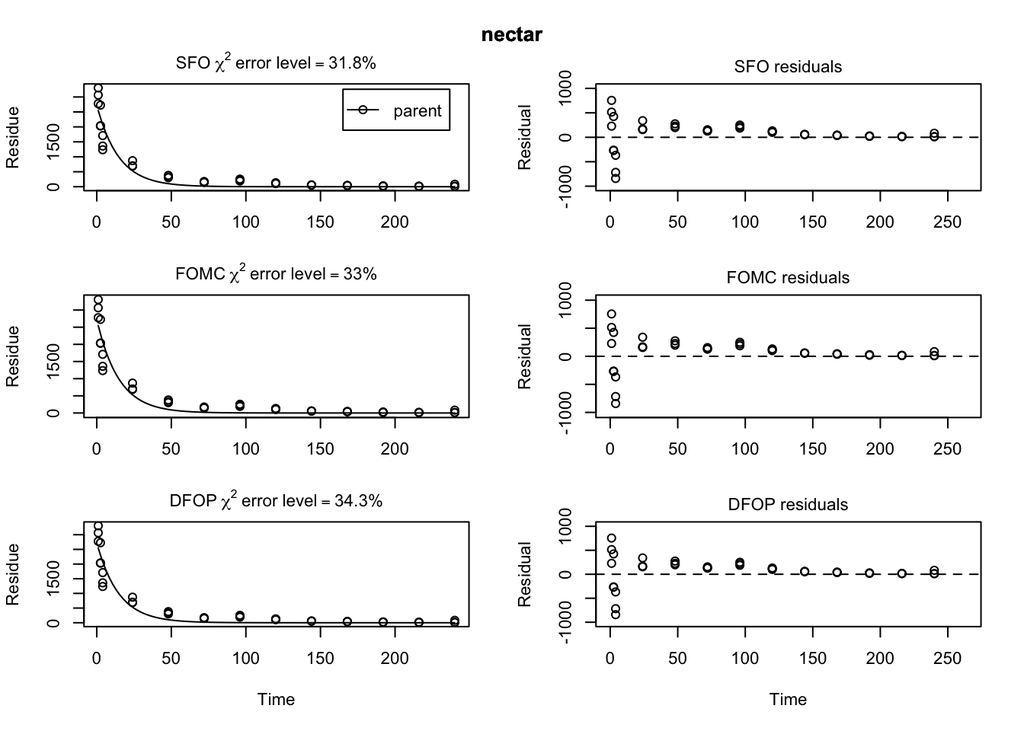

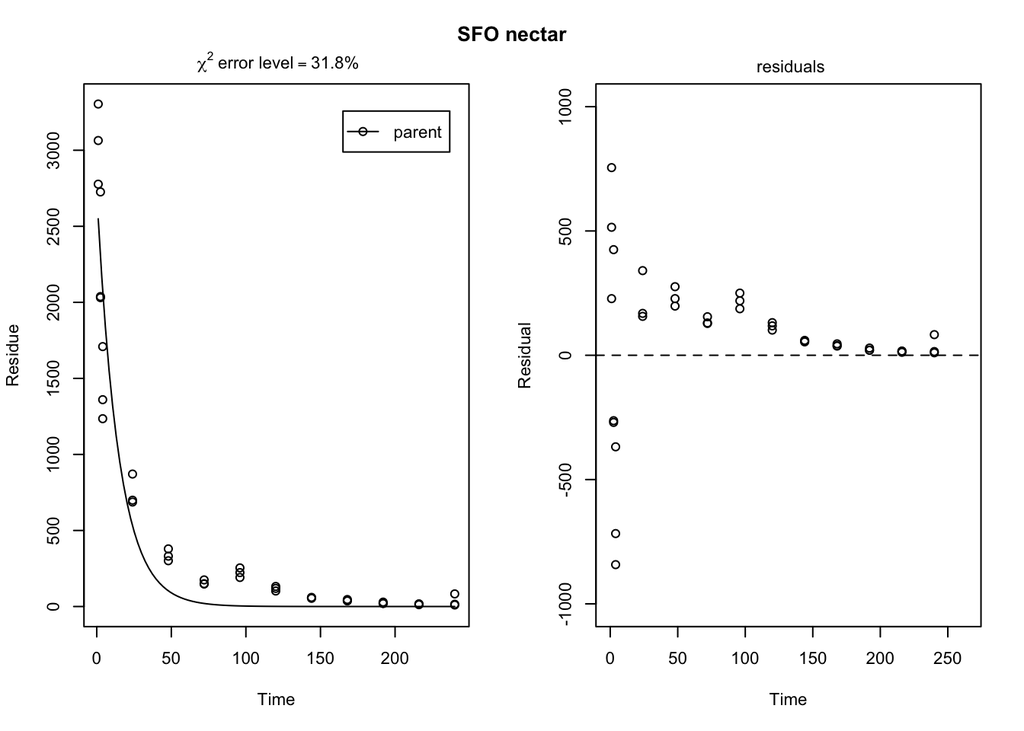

```
## mkin version used for fitting:    1.0.4
## R version used for fitting:       3.6.3
## Date of fit:     Tue Aug 10 11:50:16 2021
## Date of summary: Tue Aug 10 11:50:17 2021
##
## Equations:
## d_parent/dt = - k_parent * parent
##
## Model predictions using solution type analytical
##
## Fitted using 217 model solutions performed in 0.059 s
##
## Error model: Constant variance
##
## Error model algorithm: OLS
##
## Starting values for parameters to be optimised:
##          value   type
## parent_0 100.0  state
## k_parent   0.1 deparm
##
## Starting values for the transformed parameters actually optimised:
##                   value lower upper
## parent_0     100.000000  -Inf   Inf
## log_k_parent  -2.302585  -Inf   Inf
##
## Fixed parameter values:
## None
##
## Results:
##
##        AIC      BIC    logLik
##   557.6397 562.6304 -275.8199
##
## Optimised, transformed parameters with symmetric confidence intervals:
##              Estimate Std. Error    Lower    Upper
## parent_0     2729.000   202.3000 2319.000 3140.000
## log_k_parent   -2.685     0.3364   -3.367   -2.002
## sigma         285.200    32.3000  219.700  350.800
##
```

[output cut: 50 more lines]

```
##  144.0   parent       54 1.472e-01    53.85
##  144.0   parent       57 1.472e-01    56.85
##  144.0   parent       60 1.472e-01    59.85
##  168.0   parent       37 2.861e-02    36.97
##  168.0   parent       39 2.861e-02    38.97
##  168.0   parent       46 2.861e-02    45.97
##  192.0   parent       20 5.562e-03    19.99
##  192.0   parent       21 5.562e-03    20.99
##  192.0   parent       29 5.562e-03    28.99
##  216.0   parent       12 1.081e-03    12.00
##  216.0   parent       16 1.081e-03    16.00
##  216.0   parent       17 1.081e-03    17.00
##  240.0   parent       83 2.101e-04    83.00
##  240.0   parent       10 2.101e-04    10.00
##  240.0   parent       15 2.101e-04    15.00
```

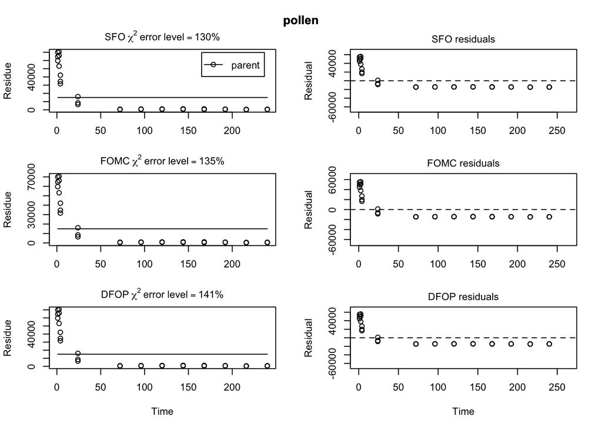

Clearly none of the models fit nectar very well. For pollen can’t even fit a model. Try with only datapoints past 24h.

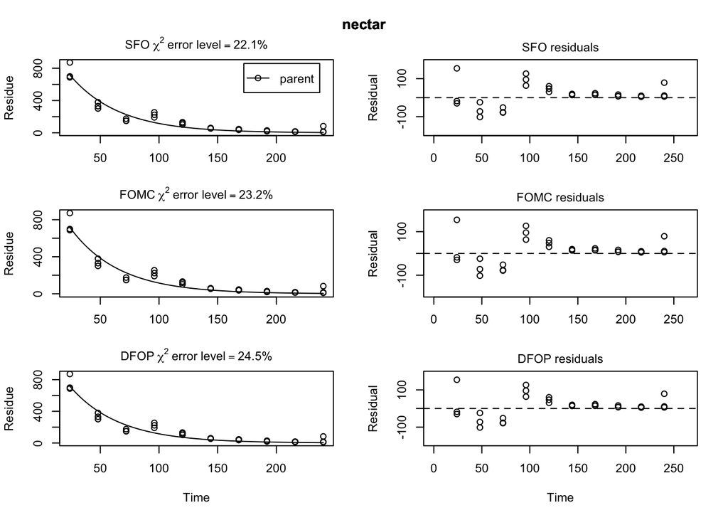

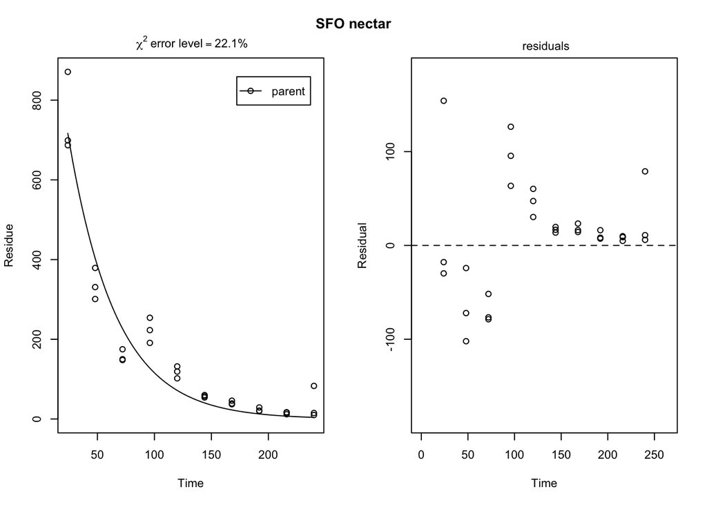

```
## mkin version used for fitting:    1.0.4
## R version used for fitting:       3.6.3
## Date of fit:     Tue Aug 10 11:50:19 2021
## Date of summary: Tue Aug 10 11:50:19 2021
##
## Equations:
## d_parent/dt = - k_parent * parent
##
## Model predictions using solution type analytical
##
## Fitted using 202 model solutions performed in 0.05 s
##
## Error model: Constant variance
##
## Error model algorithm: OLS
##
## Starting values for parameters to be optimised:
##          value   type
## parent_0 100.0  state
## k_parent   0.1 deparm
##
## Starting values for the transformed parameters actually optimised:
##                   value lower upper
## parent_0     100.000000  -Inf   Inf
## log_k_parent  -2.302585  -Inf   Inf
##
## Fixed parameter values:
## None
##
## Results:
##
##        AIC      BIC    logLik
##   334.7077 338.9113 -164.3539
##
## Optimised, transformed parameters with symmetric confidence intervals:
##              Estimate Std. Error    Lower    Upper
## parent_0      1275.00  112.20000 1044.000 1505.000
## log_k_parent    -3.73    0.09395   -3.923   -3.538
## sigma           57.95    7.48100   42.600   73.300
##
```

[output cut: 41 more lines]

```
##   144   parent       54    40.321   13.679
##   144   parent       57    40.321   16.679
##   144   parent       60    40.321   19.679
##   168   parent       37    22.676   14.324
##   168   parent       39    22.676   16.324
##   168   parent       46    22.676   23.324
##   192   parent       20    12.752    7.248
##   192   parent       21    12.752    8.248
##   192   parent       29    12.752   16.248
##   216   parent       12     7.172    4.828
##   216   parent       16     7.172    8.828
##   216   parent       17     7.172    9.828
##   240   parent       83     4.033   78.967
##   240   parent       10     4.033    5.967
##   240   parent       15     4.033   10.967
```

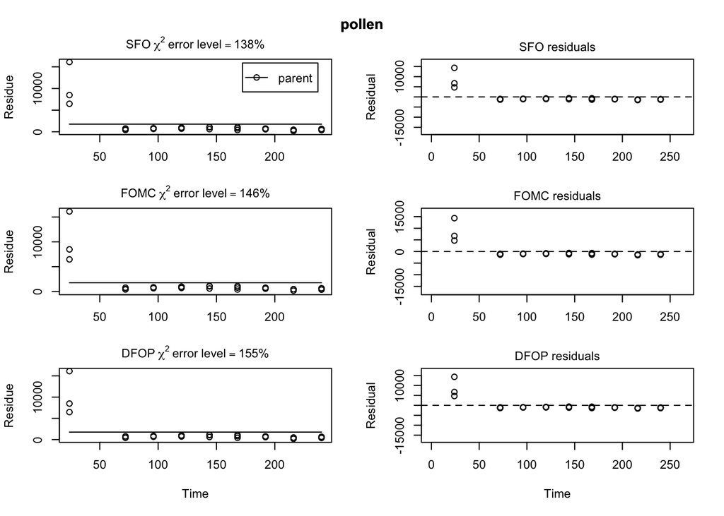

For comparing between models selecting the model with the lowest χ2 error value is easy to interpret.

Regarding the χ2 test FOCUS writes,

**The χ2 significance test indicates whether the model is probably not appropriate, i.e. demonstrating that the differences between calculated and observed are unlikely due to chance. Often α = 0.05 is used, that is a χ2 greater than χ2m,0.05 indicates that the probability that the model is not appropriate is greater than 95 %. If χ2 > tabulated χ2m,α, then the model is not appropriate at the chosen level of significance. The χ2 test considers deviations between observed and predicted values relative to the uncertainty of the measurements. Usually this isn’t known. Therefore, a percent error value is scaled with the mean of all the observed values. For this reason the χ2 test uses observed mean values.The minimum error (error-% / 100 * mean observed) at which the test is passed can be calculated. The test is passed if the calculated value of χ2 is equal to or smaller than the standard tabulated value at the 5% significance level and the given degrees of freedom. The model with the smallest error percentage is defined as most appropriate, because it describes the measured data in the most robust way. Field data will be inherently more variable than laboratory data generated under controlled conditions. Therefore, for field studies, the error percentages at which χ2 passes will generally be larger than for laboratory studies**

A less esoteric definition of χ2 error level is, *the experimental error that has to be assumed in order to explain the data from the model*. Thus, a model provides a better description of the data if less experimental error has to be assumed in order to explain the data.

My interpretation of the above is there is no cutoff for the minimum error % value to pass the test (χ2 error level) because it is situation specific. Indeed, FOCUS write, *“Note that there is no inherent value for the percent error for any given test system. The selection of an acceptable value is purely pragmatic”*. For example, for field data the χ2 error level will generally be larger due to its inherent variability relative to lab studies. Use the χ2 error level for comparison between models and look at observed vs predicted/calculated and residuals vs time graphs for assessing model fit of individual models. There needs to be no systematic error present in the residuals. In other words, residuals need to appear random.

Refs:

[FOCUS Report](https://esdac.jrc.ec.europa.eu/public_path/projects_data/focus/dk/docs/finalreportFOCDegKinetics.pdf)

[mkin Examples](https://pkgdown.jrwb.de/mkin/articles/FOCUS_L.html#laboratory-data-l3-1)